# Data Science for Public Policy

Final Project

Author

Xiangming Zeng - xz634, Ruiyang Zhang - rz326, Lingxi Li - ll1188, Xiaorui Shi - xs215

## Packages

```r
library(tidyverse)
library(sf)
library(here)
library(tigris)
library(tidycensus)
library(readxl)
library(here)
library(purrr)
library(tidymodels)
library(vip)
```

# I. Introduction

## 1. Background and Literature Review

The increasingly prominent environmental issues pose a significant challenge to human survival. The utilization of new energy sources, including renewable energy generation and the use of new energy vehicles, has highlighted the potential of policy solutions to address these environmental challenges. To what extent can the use of clean energy improve environmental quality? This question drives us to conduct this research.

There is a wealth of literature on the relationship between green energy and environmental quality. Millstein et al. (2017) argue that from 2007 to 2015, the deployment of wind and solar energy in the United States significantly reduced combustion-based electricity production, thereby decreasing overall emissions from the power sector. Their findings indicate cumulative air-quality benefits valued between $29.7 billion and $112.8 billion, primarily due to avoided premature deaths. Ganda (2018) proposes that renewable energy adoption is playing a critical role in reducing the growth in the emission of harmful gases and combatting climate change. Caglar and Askin (2023) find that economic growth and competitive industrial performance have a negative impact on environmental quality, whereas renewable energy consumption and human capital can enhance the load capacity factor. Guo et al. (2021) conclude that, in the long term, income, environmental innovation, energy industry investment, and renewable energy consumption play significant roles in explaining CO2 emissions in China. Zafar et al. (2020) argue that renewable energy has a positive impact on both environmental quality and economic growth. Besides, Evidence from Saudi Arabia shows a long-run negative and significant association between renewable energy and ecological footprint (Kahouli et al., 2022).

Evidence from around the world shows that green energy contributes to improved environmental quality. However, existing research heavily relies on macro-level data, like energy industry investment, overlooking the micro aspects of green energy consumption. Additionally, there hasn’t been enough research attention given to the role of new energy cars. To address this research gap, we aim to utilize the number of alternative fueling stations to predict air quality. Furthermore, we intend to develop a model to forecast the demand for alternative fueling stations, which is crucial for urban management in the era of new energy.

## 2. Structure of This Article

Our first two analyses are exploratory. The first one involves visualizing green electricity generation at the county and state levels, while the second one focuses on mapping alternative fueling stations in DC. These analyses are unrelated to each other and to the two subsequent machine learning analyses. Therefore, we have decided to adopt a more flexible structure, where we will not have a separate section for Data Wrangling and Exploratory Data Analysis to cover all data cleaning and new variable creation.

We initially attempted this approach, but found it to be quite messy. Instead, we believe a more appropriate way to present our findings is to include the data wrangling of the first two independent exploratory analyses directly within their respective analysis sections. This maintains their internal consistency and logical flow.

However, the two machine learning analyses rely on a single, large combined dataset called “green,” making them more consistent. Therefore, we will include a separate section before the machine learning analyses to conduct data wrangling and exploratory analysis for this commonly used dataset.

These two machine learning models are aligned with our research question. The first one is a decision tree model used to predict air quality, while the second one is a Lasso regression model used to predict the number of alternative fueling stations. Both models hold significant policy relevance in the fields of environmental and urban policy.

# II. Data Sources

For visualization purposes, the data we used only includes counties from the continental United States.

### [A. Air Quality Index Annual Summary Data (2021)](https://www.epa.gov/outdoor-air-quality-data)

This data is sourced from the U.S. Environmental Protection Agency. Our intention is to use the proportion of “good days” as a proxy for air quality in each county in 2021. We obtained the pre-generated data file for 2021 by navigating to Pre-generated Data Files -> Table of Annual Summary Data -> annual_aqi_by_county_2021.zip. This zip document contains only one CSV file, “annual_aqi_by_county_2021.csv”, which is the one we are using.

```r
c_aqi <- read.csv("data/annual_aqi_by_county_2021.csv") %>%
  janitor::clean_names() %>%
  select(state, county, days_with_aqi, good_days) %>%
#use the percent of good days to indicate air quality
  mutate(good_days_rate = 100*good_days/days_with_aqi) %>%
  select(state, county, good_days_rate)
```

### [B. Alternative Fueling Station Locations (2021)](https://catalog.data.gov/dataset/alternative-fueling-station-locations-422f2)

This dataset was created by The Alternative Fuels Data Center (AFDC). It contains the latitude and longitude information of each alternative fueling station across the U.S. It can be seen as a proxy of the usage of light-duty vehicles in each county in 2021. we downloaded the 2021 dataset, “Alternative Fuel Stations 2021.csv” ,in “Downloads & Resources” section.

```r
alt_fuel_stations <- read.csv("data/alt_fuel_stations (Jul 29 2021).csv") %>%
  janitor::clean_names() %>%
  filter(
    !is.na(longitude),
    !is.na(latitude)
  ) %>%
  st_as_sf(coords = c("longitude","latitude")) %>%
  st_set_crs(4326) %>%
  select(geometry) %>%
  mutate(facility = "Alternative Fueling Station")
```

### [C. Energy Generation: Form EIA-923 (2021)](https://www.eia.gov/electricity/data/eia923/)

This form collects detailed data, both monthly and annually, on electricity generation from all power plants in the U.S.. It includes variables such as plant name, plant code, fuel type, amount of electricity generated, amount of electricity consumed, and net generation, among others. Each plant could have more than one row if it uses different fuel types. By combining this data with Form EIA-860, we can link energy generation to corresponding plants. We downloaded the zip file for the year “2021: EIA-923” from this website, which contains three documents. We are using the one called “EIA923_Schedules_2_3_4_5_M_12_2021_Final_Revision.xlsx” because it contains annual net electricity generation data.

```r
elec_generation <- read_excel("data/EIA923_Schedules_2_3_4_5_M_12_2021_Final_Revision.xlsx",
                              sheet = 1, skip = 5) %>%
  janitor::clean_names() %>%
  mutate(plant_code = plant_id,
         fuel_type = aer_fuel_type_code,
         net_generation = net_generation_megawatthours) %>%
  select(plant_code, fuel_type, net_generation)
```

### [D. Power Plant: Form EIA-860 (2021)](https://www.eia.gov/electricity/data/eia860/)

The Form EIA-860 collects specific information about existing and planned electric power plants with a combined nameplate capacity of 1 megawatt or greater. It includes details such as plant name, plant code, and geographical information like county, state, longitude, and latitude. This data can be combined with Form EIA-923 to calculate energy generation at the county level. We downloaded the zip file for the year 2021 from the website, which contains 13 documents. We are using the “2___Plant_Y2021.xlsx” file, which provides plant-level information.

```r
plants <- read_excel("data/2___Plant_Y2021.xlsx", skip=1) %>%
  janitor::clean_names() %>%
  select(plant_code, latitude, longitude)
```

### [E. NCHS Urban-Rural Classification (2013)](https://www.cdc.gov/nchs/data_access/urban_rural.htm)

Given the significance of urbanization in determining air quality and the demand for alternative fueling stations, we included the NCHS Urban-Rural Classification as a measure of urbanization level. This classification system categorizes all U.S. counties into six groups, ranging from 1 (large central metro) to 6 (non-core). We obtained the “NCHSURCodes2013.xlsx” file from the website’s “Data Files and Documentation” section, as the 2013 version is the latest available. We assume that county urbanization levels remain relatively stable over a decade.

```r
c_urban <- read_xlsx("data/NCHSURCodes2013.xlsx") %>%
  janitor::clean_names() %>%
  select(state_abr, county_name, urban = x2013_code) %>%
  #reverse coding, using 1-6 to represent increasing urban rate
  mutate(urban = 7 - urban)
```

### F. DC Public Facilities

To explore the accessibility to alternative fueling stations in DC, we downloaded geojson documents of [hospitals](https://hub.arcgis.com/datasets/5de949289bb248fc842f3b8324f28eda_0/explore), [public schools](https://hub.arcgis.com/datasets/4ac321b2d409438ebd76a6569ad94034_5/explore), [charter schools](https://hub.arcgis.com/datasets/a3832935b1d644e48c887e6ec5a65fcd_1/explore), [university/college campuses](https://hub.arcgis.com/datasets/2cc7c37a61554ad181c6356023c8532c_13/explore), and [governmental buildings](https://hub.arcgis.com/datasets/f04fe795a8dd4f04a73bcc1250e20a0a_77/explore) from their websites respectively. All data are provided by Open Data DC. Besides, we used sf::roads() to get DC roads data.

```r
dc_roads <- roads(state = "DC",
                  county = "District of Columbia",
                  progress_bar=F) %>%
  st_transform(crs = 4269)

dc_hospitals <- st_read("data/DC_Hospitals.geojson",
                        quiet=T) %>%
  st_transform(crs = 4326) %>%
  select(geometry) %>%
  mutate(facility = "Hospital")

dc_cha_schs <- st_read("data/DC_Charter_Schools.geojson",
                       quiet=T) %>%
  st_transform(crs = 4326) %>%
  select(geometry) %>%
  mutate(facility = "Charter School")

dc_pub_schs <- st_read("data/DC_Public_Schools.geojson",
                       quiet=T) %>%
  st_transform(crs = 4326) %>%
  select(geometry) %>%
  mutate(facility = "Public School")

dc_campuses <- st_read("data/University_and_College_Campuses.geojson",
                       quiet=T) %>%
  st_transform(crs = 4326) %>%
  select(geometry) %>%
  mutate(facility = "University/College Campus")

dc_gov <- st_read("data/District_Government_Owned_Structures.geojson",
                  quiet=T) %>%
  st_transform(crs = 4326) %>%
  select(geometry) %>%
  mutate(facility = "Governmental Building")
```

### G. American Community Survey (2017-2021)

We utilized socio-economic data from the American Community Survey (ACS), including household income (B19013_001), population (B01003_001), Bachelor’s degree (B15003_022E), and workers age 16+ (B08007_001E). These variables offer basic economic and social insights for each county.

Additionally, we incorporated energy consumption data from the ACS, encompassing utility gas (B25040_002E), bottled gas (B25040_003E), electricity (B25040_004E), oil (B25040_005E), coal (B25040_006E), and wood (B25040_007E). We consider energy consumption a crucial predictor for air quality.

Furthermore, we included transportation-to-work data, such as drive alone (B08301_003E), carpooled (B08301_004E), public transportation (B08301_010E), taxicab (B08301_016E), motorcycled (B08301_017E), bicycled (B08301_018E), and walked (B08301_019E). We believe transportation methods significantly impact both air quality and the demand for alternative fueling stations.

To combine above data with a large dataframe named “green,” we developed a function using an API. Since we don’t have “green” here in this step, it’s not convenient to display it here, but you can view it in section IV/1/B.

Additionally, we utilized ACS data to obtain household income in DC.

```r
dc_income <- get_acs(
  geography = "tract",
  variables = "B19013_001",
  state = "DC",
  county = "District of Columbia",
  geometry = TRUE,
  year = 2021,
  progress = FALSE
)
```

# III. Two Spatial Exploratory Data Analyses

## 1. Overview: Green Electricity Generation In The U.S.

With the increasing global awareness of environmental protection and the drive for environmental movements, green energy generation is becoming a trend. What is the spatial distribution of green energy generation in the United States? Which states are leading in green energy generation? What are the different geographical distribution characteristics of different green energy generation methods? In this section, we attempt to address these questions.

### A. Data wrangling

```r
#combine datasets
elec_generation <- left_join(x = elec_generation,y = plants,by = "plant_code") %>%
  filter(
    !is.na(longitude),
    !is.na(latitude)
  ) %>%
  st_as_sf(coords = c("longitude","latitude")) %>%
  st_set_crs(4326)

#filter green electricity generation
green_elec_generation <- elec_generation %>%
  filter(fuel_type %in% c("SUN","GEO","HPS","HYC","MLG","ORW","WND","WWW"))

#read counties data
counties <- counties(cb = TRUE, progress_bar = FALSE) %>%
  janitor::clean_names() %>%
  st_transform(crs = 4326) %>%
  filter(!(stusps %in% c("PR", "GU", "MP", "VI", "HI", "AK", "AS"))) %>%
  select(geoid, name, namelsad, stusps, state_name, geometry)

#use spatial join to get green electricity generated in each county
c_green_elec <- st_join(counties, green_elec_generation) %>%
  st_drop_geometry() %>%
  group_by(geoid) %>%
  summarize(green_elec = sum(net_generation)) %>%
  mutate(green_elec = replace_na(green_elec, 0))

#combine datasets to get geometry for c_green_elec
c_green_elec <- left_join(counties, c_green_elec, by = "geoid")

#sum county-level data to state level
s_green_elec <- c_green_elec %>%
  st_drop_geometry() %>%
  group_by(stusps) %>%
  summarise(green_elec = sum(green_elec))

#read states data
states <- states(cb = TRUE, progress_bar = FALSE) %>%
  janitor::clean_names() %>%
  st_transform(crs = 4326) %>%
  filter(!(stusps %in% c("PR", "GU", "MP", "VI", "HI", "AK", "AS"))) %>%
  select(stusps, geometry)

#combine datasets to get geometry for s_green_elec
s_green_elec <- left_join(states, s_green_elec, by = "stusps")

#filter plants with green electricity generation within states
green_elec_generation <- st_filter(green_elec_generation, states)

#identify 3 most common fuel types
green_elec_generation %>%
  group_by(fuel_type) %>%
  summarise(n = n()) %>%
  arrange(-n)
```

```
Simple feature collection with 8 features and 2 fields
Geometry type: MULTIPOINT
Dimension:     XY
Bounding box:  xmin: -124.2103 ymin: 25.54983 xmax: -67.4012 ymax: 48.99687
Geodetic CRS:  WGS 84
# A tibble: 8 × 3
  fuel_type     n                                                       geometry
  <chr>     <int>                                               <MULTIPOINT [°]>
1 SUN        4496 ((-69.12333 44.17362), (-69.357 44.598), (-68.991 45.267), (-…
2 HYC        1373 ((-68.5453 45.6072), (-69.96782 43.92049), (-68.4306 44.5442)…
3 WND        1261 ((-67.8111 46.54422), (-68.14722 46.05806), (-67.971 45.61498…
4 MLG         416 ((-68.8258 44.7383), (-68.86167 44.76861), (-69.8319 44.7014)…
5 WWW         308 ((-67.5477 44.6781), (-68.8258 44.7383), (-69.2019 44.3331), …
6 ORW         202 ((-69.2019 44.3331), (-70.54429 44.5465), (-70.5414 44.5513),…
7 GEO          70 ((-117.4681 44.02306), (-120.5578 42.69583), (-122.881 38.833…
8 HPS          41 ((-118.9773 47.95751), (-121.6301 39.51489), (-121.0477 37.09…
```

In state-level visualization, we will explore the distribution pattern of the three most common green electricity fuel types: sun, hydroelectric conventional, and wind.

### B. County-level distribution of green electricity generation

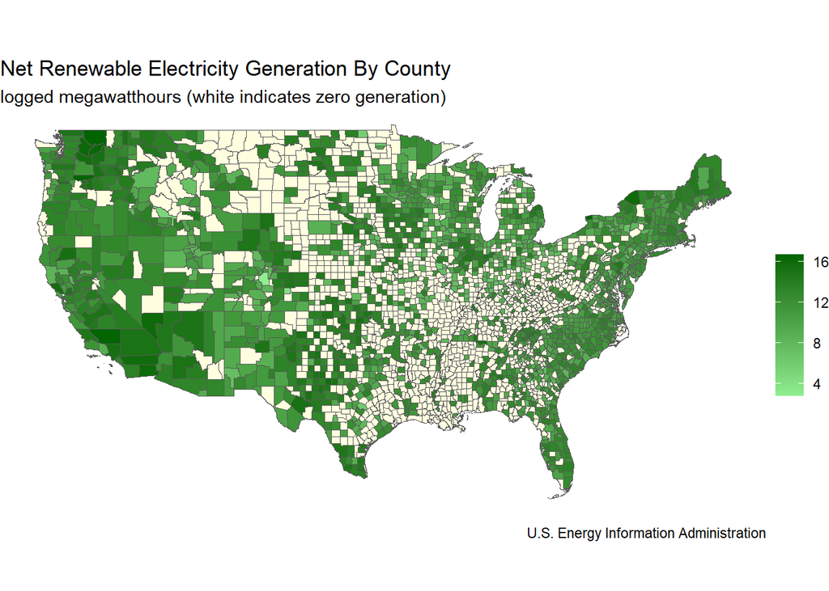

```r
#visualize green electricity generation at county-level
ggplot()+
  geom_sf(c_green_elec, mapping = aes(fill = log(green_elec)))+
  scale_fill_gradient(
    low = "lightgreen",
    high = "darkgreen",
    na.value = "lightyellow"
  )+
  labs(title = "Net Renewable Electricity Generation By County",
       subtitle = "logged megawatthours (white indicates zero generation)",
       caption = "U.S. Energy Information Administration",
       fill = "") +
  theme_void()
```

From the graph, we can see that green electricity production is mainly distributed along the East Coast, the West, and the Northeast in the United States, while it is relatively lacking in the center.

### C. State-level distribution of green electricity generation

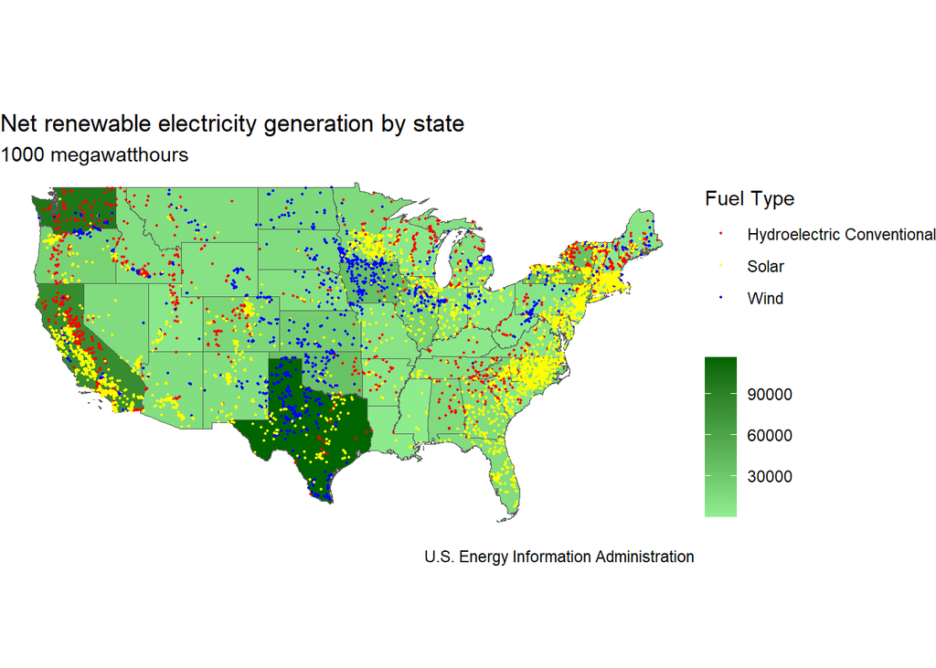

```r
#visualize green electricity generation at state-level
ggplot()+
  geom_sf(s_green_elec, mapping = aes(fill = green_elec/1000))+
  scale_fill_gradient(
    low = "lightgreen",
    high = "darkgreen"
  )+
  geom_sf(data = green_elec_generation %>%
            filter(fuel_type %in% c("HYC", "SUN", "WND")),
          mapping = aes(color = fuel_type), size=0.3)+
  labs(title = "Net renewable electricity generation by state",
       subtitle = "1000 megawatthours",
       caption = "U.S. Energy Information Administration",
       fill = "",
       color = "plants with green electricity generation") +
  scale_color_manual(
    name = "Fuel Type",
    labels = c("HYC" = "Hydroelectric Conventional", "SUN" = "Solar", "WND" = "Wind"),
    values = c("HYC" = "red", "SUN" = "yellow", "WND" = "blue")) +
  theme_void()
```

From the graph, we can see that California, Washington, and Texas are leading in green electricity production. Additionally, power plants of different energy types have distinct spatial distribution characteristics. Solar energy is mainly concentrated on the East and West Coasts, wind energy is mainly concentrated in the central inland areas, while the distribution of hydroelectric conventional is more dispersed.

```r
#remove used dataframes
rm(green_elec_generation, plants, s_green_elec)
```

## 2. A Micro Case: Alternative Fueling Stations In DC

Let’s move from the map of the United States back to DC. What are the geographical distribution characteristics of alternative fueling stations in DC? Which socioeconomic groups have poor accessibility to them? Which public facilities are often adjacent to them? In this section, we intend to explore these micro questions.

### A. Data wrangling

```r
#read boundry data
dc_boundary <- states(cb = TRUE, progress_bar = FALSE) %>%
  filter(STUSPS == "DC") %>%
  st_transform(crs = 4326)

#filter alternative fueling stations in DC
dc_alt_fuel_stations <- st_filter(alt_fuel_stations, dc_boundary)

#combine datasets
facilities <- bind_rows(dc_hospitals,
                        dc_cha_schs,
                        dc_pub_schs,
                        dc_campuses,
                        dc_gov,
                        dc_alt_fuel_stations)
```

### B. Data visualization

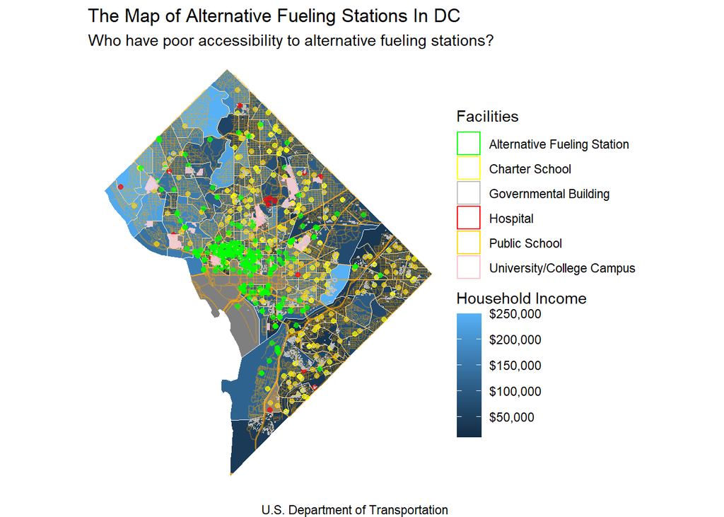

```r
#mapping facilities
ggplot()+
  geom_sf(data = dc_income, aes(fill = estimate), color = "white", size = 0)+
  geom_sf(data = dc_roads, color = "orange", alpha = 0.3)+
  geom_sf(data = facilities, aes(color = facility), fill = "white", alpha = 0.7)+
  scale_fill_gradient(
    labels = scales::dollar
  )+
  scale_color_manual(values = c(
    "Alternative Fueling Station" = "green",
    "Charter School" = "yellow",
    "Governmental Building" = "grey",
    "Hospital" = "red",
    "Public School" = "gold",
    "University/College Campus" = "pink"
  ))+
  geom_sf(data = dc_campuses, color = "pink", fill = "pink", alpha = 0.5)+
  theme_void()+
  labs(
    title = "The Map of Alternative Fueling Stations In DC",
    subtitle = "Who have poor accessibility to alternative fueling stations?",
    caption = "U.S. Department of Transportation",
    fill = "Household Income",
    color = "Facilities")
```

From the map, we can see that alternative fueling stations are concentrated in the downtown area of DC, while outside the downtown area, they are mainly clustered along the main roads. University campuses generally have good accessibility to alternative fueling stations. However, Hospitals on the outskirts of the city have poor accessibility to alternative fueling stations.

In the northwest of DC, where the household income is the highest, the distribution of alternative fueling stations is relatively even, and residents and schools have good accessibility to them. In the northeast of DC, although the household income is lower, the distribution of alternative fueling stations is still relatively even.

In the eastern part, where the household income further decreases, despite the presence of numerous schools and government buildings, there are only few and concentrated alternative fueling stations, resulting in poor accessibility. In the southern part, where the household income is low and there are many schools, hospitals, and government buildings, the number of alternative fueling stations is few and mainly located along the main roads, leading to poor accessibility.

Overall, alternative fueling stations are concentrated in the downtown area of DC, and the household income of neighborhoods is highly correlated with the accessibility of alternative fueling stations. Groups with disadvantaged socio-economic status face difficulties in accessing new energy charging facilities.

```r
#remove used dataframes
rm(dc_boundary,
   dc_income,
   dc_roads,
   dc_hospitals,
   dc_cha_schs,
   dc_pub_schs,
   dc_campuses,
   dc_gov,
   dc_alt_fuel_stations,
   facilities)
```

# IV. Data Wrangling and Exploratory Data Analysis For Machine Learning

## 1. Data Cleaning

### A. Combine existing data

```r
# count the number of alternative fueling stations in each county
c_fueling_stations <- st_join(counties, alt_fuel_stations) %>%
  st_drop_geometry() %>%
  group_by(geoid) %>%
  summarize(alt_fuel_stations = n())

# sum the total electricity generation in each county
c_total_elec <- st_join(counties, elec_generation) %>%
  st_drop_geometry() %>%
  group_by(geoid) %>%
  summarize(total_elec = sum(net_generation)) %>%
  mutate(total_elec = replace_na(total_elec, 0))

#combine all county-level datasets
green <- left_join(c_green_elec, c_total_elec, by = "geoid")
green <- left_join(green, c_fueling_stations, by = "geoid")
green <- left_join(green, c_aqi, by = c("state_name" = "state", "name" = "county"))
green <- left_join(green, c_urban, by = c("stusps" = "state_abr", "namelsad" = "county_name"))
```

### B. Combine ACS data

```r
#create a function
acs_combine <- function(variable, name) {
df <- get_acs(
    geography = "county",
    variables = variable,
    year = 2021,
    progress = FALSE
  ) %>%
    janitor::clean_names() %>%
    select(geoid, {{ name }} := estimate)

green <<- left_join(green, df, by = "geoid")

invisible()
}

#create a list for new acs variables
variables <- list(
  variable = c("B19013_001",
               "B01003_001",
               "B15003_022E",
               "B08007_001E",
               "B25040_002E",
               "B25040_003E",
               "B25040_004E",
               "B25040_005E",
               "B25040_006E",
               "B25040_007E",
               "B08301_003E",
               "B08301_004E",
               "B08301_010E",
               "B08301_016E",
               "B08301_017E",
               "B08301_018E",
               "B08301_019E"
               ),
  name = c("income",
           "population",
           "bachelor",
           "labor",
           "utility_gas",
           "bottled_gas",
           "electricity",
           "oil",
           "coal",
           "wood",
           "drive_alone",
           "carpooled",
           "public_trans",
           "taxicab",
           "motorcycled",
           "bicycled",
           "walked"
          )
)

#combine
pwalk(variables, acs_combine)
```

### C. Remove irrelevant features

```r
#remove irrelavant variables
green <- green %>%
  select(-geoid, -name, -namelsad, -stusps, -state_name) %>%
  st_drop_geometry()

#remove used datasets
rm(alt_fuel_stations,
   c_aqi,
   c_fueling_stations,
   c_green_elec,
   c_total_elec,
   c_urban,
   elec_generation,
   variables)
```

### D. Generate new variables

```r
#generate new variables
green <- green %>%
  mutate(green_elec_prop = 100*green_elec/total_elec) %>%
  mutate(labor_prop = 100*labor/population) %>%
  mutate(bachelor_prop = 100*bachelor/population) %>%
  mutate(totoal_energy_cons = utility_gas+bottled_gas+electricity+oil+coal+wood) %>%
  mutate(clean_energy_prop = 100*(utility_gas+bottled_gas+electricity)/totoal_energy_cons) %>%
  mutate(trad_energy_prop = 100*(oil+coal+wood)/totoal_energy_cons) %>%
  mutate(clean_trans_prop = 100*(public_trans+bicycled+walked)/labor) %>%
  mutate(auto_trans_prop = 100*(drive_alone+carpooled+taxicab+motorcycled)/labor) %>%
  select(-totoal_energy_cons) %>%
  mutate(afs_per_1000_drivers = 1000*alt_fuel_stations/drive_alone)
```

## 2. Missing Values and Unexpected Values

### A. Missing values

Good_days_rate has approximately 2000 missing values. This is because the AQI dataset only contains observations from about 1000 counties. Since air quality can vary significantly even within one state, filling NA with the mean air quality is not reasonable. Therefore, we will leave them as NA and only use this variable in the first machine learning model where it serves as the dependent variable. In the second machine learning model, we will drop it to maintain a large sample size.

There are also missing values generated in the previous step. The generated variable green_elec_prop has many missing values because many counties have zero electricity generation. I will replace NA with 0 because logically, for counties without electricity generation, their proportion of green electricity in total electricity generated should be zero.

```r
green <- green %>%
  mutate(green_elec_prop = if_else(is.na(green_elec_prop), 0, green_elec_prop))
```

### B. Unexpected values

We have encountered unexpected values in green_elec_prop. It appears that we have obtained negative proportions. However, after considering the definitions of green_elec and total_elec, we realized this is not an error. Both of these variables represent net electricity generation. Since power plants also consume electricity, these values can be negative. Therefore, we will retain those negative proportions.

```r
summary(green$green_elec_prop)
```

```
     Min.   1st Qu.    Median      Mean   3rd Qu.      Max.
-183.8265    0.0000    0.9484   38.7667  100.0000  141.1966
```

## 3. Exploratory Analysis

Is the green energy industry related to air quality? Before conducting machine learning, we can conduct exploratory analysis using scatter plots.

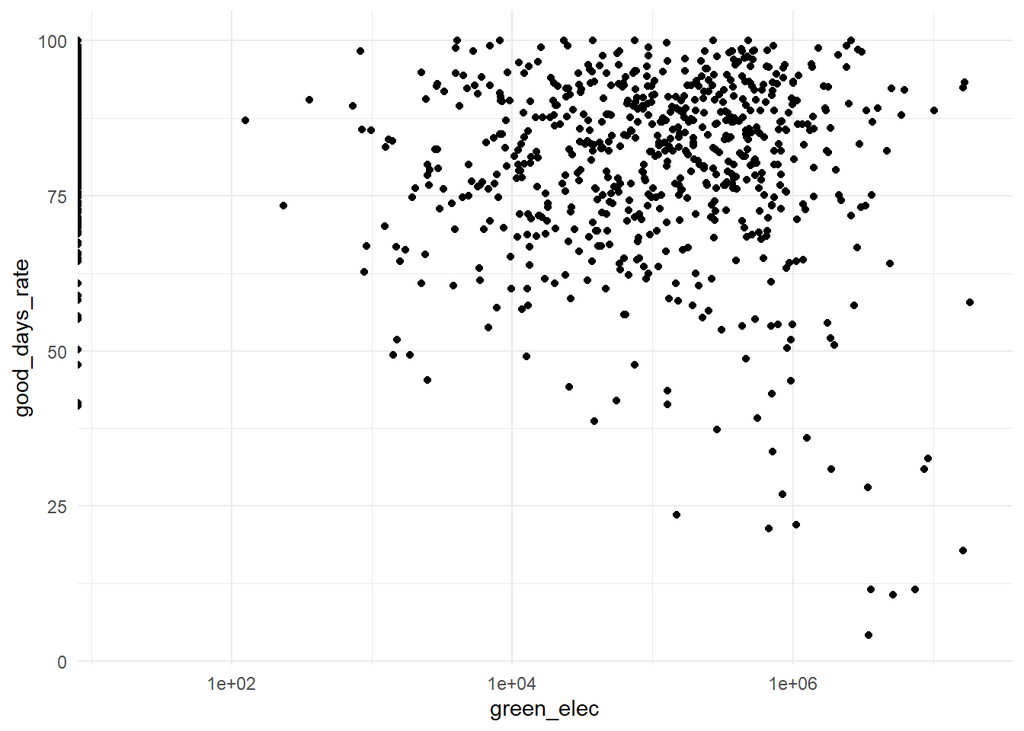

```r
#The relationship between green electricity generation and air quality
ggplot(data = green)+
  geom_point(mapping = aes(x = green_elec, y = good_days_rate))+
  scale_x_log10()+
  theme_minimal()
```

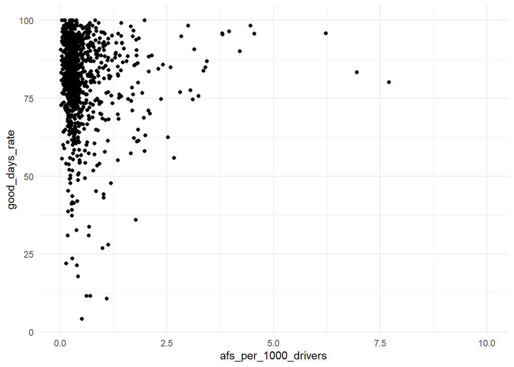

```r
#The relationship between alternative fueling stations density and air quality
ggplot(data = green)+
  geom_point(mapping = aes(x = afs_per_1000_drivers, y = good_days_rate))+
  scale_x_continuous(limits = c(0, 10))+
  theme_minimal()
```

In these two graphs, it appears that there is no clear relationship between either green electricity generation or alternative fueling stations density and air quality. In short, there is no clear relationship between the green energy industry and air quality. Therefore, we should conduct a machine learning analysis to further test our hypothesis.

# V. Machine Learning

## 1. Can Green Energy Industry Help Predict Air Quality?

Since green energy use (alternative energy cars) and production (green electricity) are more environmental-friendly, we expect that green energy industry is a critical predictor for air quality. In this section, we will use a decision tree model to test this hypothesis.

We chose to use a decision tree model because our objective is classification. In other words, we are not concerned about the specific values of the air quality index or the proportion of days recorded as “good.” Instead, we are interested in establishing a threshold that distinguishes between “good” and “bad” air quality. For instance, if 80% of days in a county are classified as “good,” we generally consider this county to have good air quality.

### A. Data cleaning

```r
#remove rows with missing air quality
air <- green %>% filter(!is.na(good_days_rate))

#turn good_days_rate into dummy
summary(air$good_days_rate)
```

```
   Min. 1st Qu.  Median    Mean 3rd Qu.    Max.
   4.11   75.07   83.98   81.20   91.24  100.00
```

### B. Dummy variable generation

The median of good_days_rate is 84, and mean is 81, so we choose to code air_quality as “good” if good_days_rate > 80, and as “bad” if good_days_rate <= 80.

```r
air <- air %>%
  mutate(air_quality = if_else(good_days_rate > 80, "good", "bad")) %>%
  mutate(air_quality = factor(air_quality, levels = c("good", "bad"))) %>%
  select(-good_days_rate)
```

### C. Decision tree model

```r
set.seed(20240508)

#split data
air_split <- initial_split(data = air, prop = 0.75)

air_train <- training(x = air_split)
air_test <- testing(x = air_split)

#create a recipe
air_rec <-
  recipe(formula = air_quality ~ ., data = air_train)

#create a model
air_mod <-
  decision_tree() %>%
  set_engine(engine = "rpart") %>%
  set_mode(mode = "classification")

air_wf <- workflow() %>%
  add_recipe(air_rec) %>%
  add_model(air_mod)

#fit the model
air_fit <- air_wf %>%
  fit(data = air_train)
```

### D. Evaluate model

```r
#evaluate model
predictions <- bind_cols(
  air_test,
  predict(object = air_fit, new_data = air_test),
  predict(object = air_fit, new_data = air_test, type = "prob")
)

#confusion matrix
conf_mat(data = predictions,
         truth = air_quality,
         estimate = .pred_class)
```

```
          Truth
Prediction good bad
      good  112  47
      bad    29  50
```

```r
#accuracy
accuracy(data = predictions,
         truth = air_quality,
         estimate = .pred_class)
```

```
# A tibble: 1 × 3
  .metric  .estimator .estimate
  <chr>    <chr>          <dbl>
1 accuracy binary         0.681
```

```r
#precision
precision(data = predictions,
         truth = air_quality,
         estimate = .pred_class)
```

```
# A tibble: 1 × 3
  .metric   .estimator .estimate
  <chr>     <chr>          <dbl>
1 precision binary         0.704
```

```r
#recall
recall(data = predictions,
          truth = air_quality,
          estimate = .pred_class)
```

```
# A tibble: 1 × 3
  .metric .estimator .estimate
  <chr>   <chr>          <dbl>
1 recall  binary         0.794
```

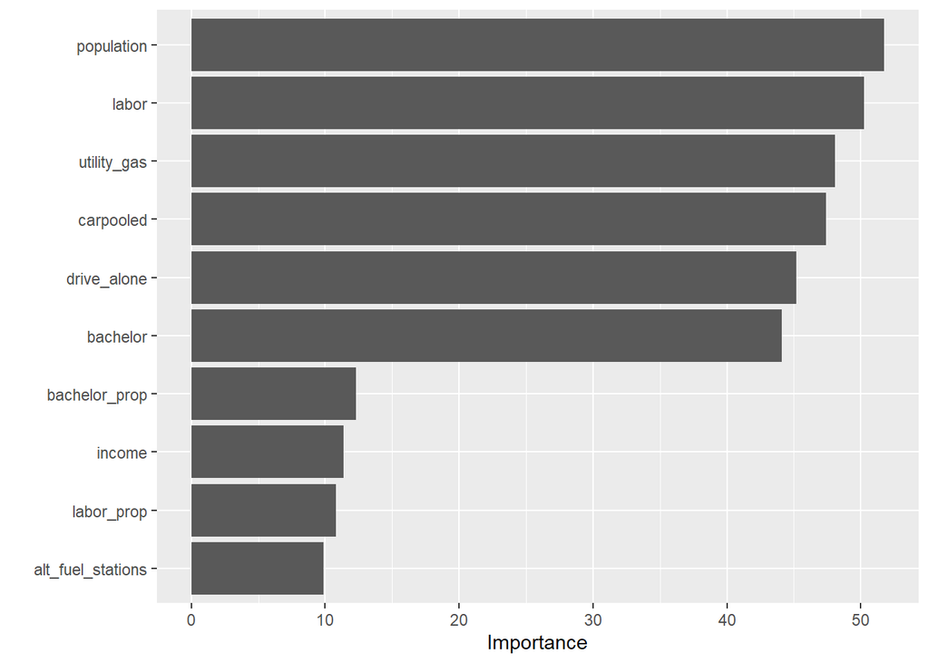

```r
#feature importance
air_fit %>%
  extract_fit_parsnip() %>%
  vip(num_features = 10)
```

In this predictive model, the accuracy is 0.681, while precision and recall fall between 0.7 and 0.8, indicating relatively weak predictive power. Therefore, this model does not perform very well in predicting air quality. Additionally, the ten most important predictors do not include green_elec or green_elec_prop. However, drive_alone, carpooled and alt_fuel_stations are significant predictors. This suggests that while green electricity generation is not a good predictor, citizens’ commuting preferences, especially the preference for driving, are significant predictors for air quality. Moreover, the use of new energy vehicles is a significant predictor, as the ten most important predictors includes alt_fuel_stations.

```r
# Remove irrelevant data
rm(air,
   air_fit,
   air_mod,
   air_rec,
   air_split,
   air_test,
   air_train,
   air_wf,
   predictions)
```

## 2. What’s The Key Predictors For Alternative Fueling Stations?

With the development of the green energy car industry, the demand for alternative fueling stations is increasing. Is there a shortage of alternative fueling stations in DC? To address this question, we will establish a lasso regression model to identify the most significant predictors for the number of alternative fueling stations in a city. We believe this model will be highly relevant for policymakers in urban areas.

We are utilizing a lasso regression model because we aim to predict the precise number of alternative fueling stations in each county. We opt for Lasso regression over normal regression because it applies a penalty to prevent overfitting and improve accuracy. To find the optimal model, we will employ hyperparameter tuning and resampling methods.

### A. Data cleaning

Due to more than 2000 missing values in good_days_rate, we remove it to avoid having too small of a sample size.

```r
green <- green %>%
  select(-good_days_rate)
```

### B. Lasso regression model

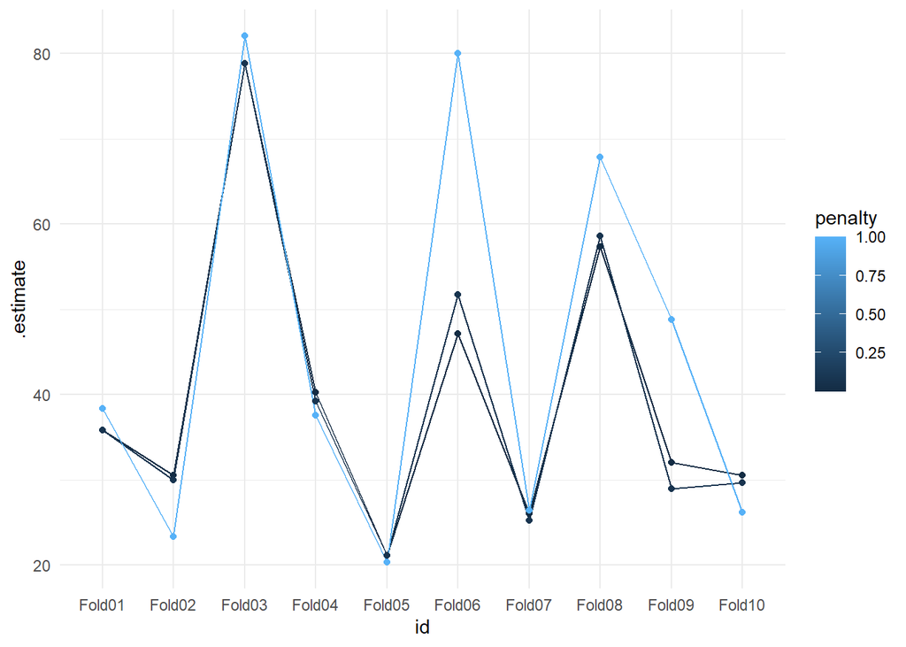

```r
#split data
green_split <- initial_split(green, prop = 0.75)

green_train <- training(green_split)
green_test <- testing(green_split)

#create a recipe
green_rec <- recipe(alt_fuel_stations ~ . , data = green_train) %>%
  step_filter_missing(all_predictors()) %>%
  step_normalize(all_numeric_predictors()) %>%
  step_impute_median(all_numeric_predictors(), all_nominal_predictors())

#create a lasso model
lasso_green <- linear_reg(penalty = tune(), mixture = 1) %>%
  set_engine("glmnet") %>%
  set_mode("regression")

folds <- vfold_cv(green_train, v = 10, strata = alt_fuel_stations)

lasso_grid <- grid_regular(penalty(), levels = 10)

lasso_wf_green <- workflow() %>%
  add_recipe(green_rec) %>%
  add_model(lasso_green)

#fit model
lasso_res_green <- lasso_wf_green %>%
  tune_grid(resample = folds,
            grid = lasso_grid,
            metrics = metric_set(mae,rmse))

#visualize model fit
lasso_res_green %>%
  collect_metrics(summarize=F) %>%
  filter(.metric=="rmse") %>%
  ggplot(aes(x=id,y=.estimate, group=penalty, color=penalty),alpha=0.5)+
  geom_line()+
  geom_point()+
  theme_minimal()
```

### C. Evaluate model

```r
#select best model
lasso_best_green <-lasso_res_green %>%
  select_best(metric = "rmse")

#finalize model
lasso_final_green <- finalize_workflow(
  lasso_wf_green,
  parameters = lasso_best_green) %>%
  fit(data = green_train)

#predict
predictions <- bind_cols(
  green_test,
  predict(object = lasso_final_green, new_data = green_test))

#calculate rmse
rmse(data = predictions, truth = alt_fuel_stations, estimate=.pred)
```

```
# A tibble: 1 × 3
  .metric .estimator .estimate
  <chr>   <chr>          <dbl>
1 rmse    standard        24.4
```

```r
summary(green_test$alt_fuel_stations)
```

```
   Min. 1st Qu.  Median    Mean 3rd Qu.    Max.
   1.00    1.00    2.00   15.52    8.00 1145.00
```

The RMSE is 24.4, which is relatively small compared to the range of 1144. However, considering the mean number of alternative fueling stations is 15.52 (since most counties are not urban areas), this model will be more applicable in large cities where the number of alternative fueling stations is significantly higher.

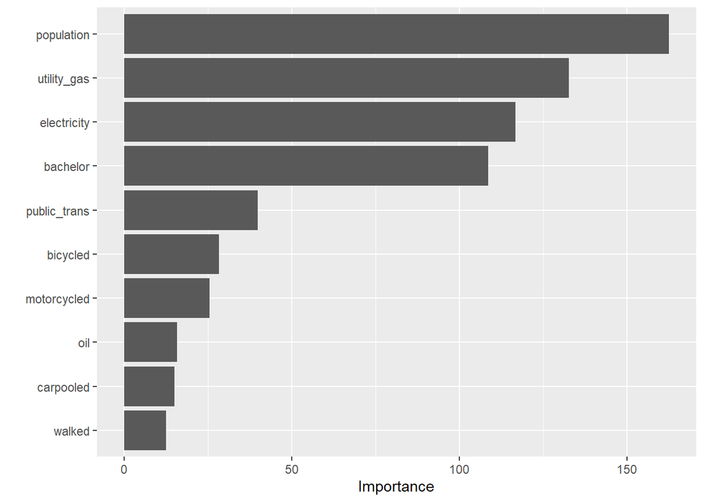

```r
#feature inportance
lasso_final_green %>%
  extract_fit_parsnip() %>%
  vip(num_features = 10)
```

The four most significant predictors are population, utility gas consumption, electricity consumption, and population with Bachelor’s degree. All of these variables have a clear correlation with the demand for alternative fueling stations. Additionally, the remaining key, albeit less significant, factors are primarily related to modes of transportation, indicating that citizens’ preferences for cleaner transportation methods such as public transportation, cycling, motorcycling, and walking are also relevant to their demand for alternative fueling stations.

# VI. Conclusion and Discussion

## 1. Conclusions

To address the first research question, “can the use of clean energy improve environmental quality,” we developed a decision tree model. The model exhibits relatively low predictive power (accuracy = 0.681). This could be attributed to the complexity of air quality, as there are numerous factors influencing it. However, alternative fueling stations are among the 10 most important predictors, appearing as the last one, suggesting that the use of new energy vehicles may contribute to predicting air quality, albeit with a moderate correlation.

Conversely, green electricity generation does not emerge as a significant predictor for air quality.In conclusion, it appears that energy consumption patterns are more influential in predicting air quality than energy production methods. This notion warrants further research.

The key predictors identified are population, utility gas consumption, electricity consumption, and population with Bachelor’s degrees, which align with common sense. What’s interesting is that other clean commuting patterns, like public transportation, cycling, motorcycling, and walking, are also important predictors for citizens’ demand for alternative fueling stations. The relationship between different transportation preferences deserves further study.

## 2. Limitations

Due to time constraints and limitations in available data, this study has some limitations.

Firstly, our sample size is too small, especially when predicting air quality, as we only have around 1000 observations due to missing values. If alternative data covering air quality for all counties in the United States could be found, our predictions might be more accurate.

Additionally, we have included too few variables. We only included the most basic socio-economic variables, energy consumption variables, and transportation mode variables. However, more variables related to pollution, such as data on sources of pollution other than the energy industry (such as manufacturing), have not been included. Future researchers should consider more comprehensive variables.

Lastly, the data we used may not be precise. For example, we used alternative fueling stations as a proxy for the number of new energy vehicles to predict air quality, but this approach is crude and may not accurately reflect the relationship between new energy vehicles and air quality. Additionally, when predicting the number of alternative fueling stations, we did not use the most important predictor, the number of new energy bicycles, because we did not have access to this data. Future research should use more accurate data, such as community survey data, to estimate the number of new energy vehicles, thus obtaining more precise predictions.

# References

Millstein, D., Wiser, R., Bolinger, M. et al. The climate and air-quality benefits of wind and solar power in the United States. Nat Energy 2, 17134 (2017). https://doi.org/10.1038/nenergy.2017.134

Ganda, F. (2018). The influence of green energy investments on environmental quality in OECD countries. Environmental Quality Management, 28(2), 17–29. https://doi.org/10.1002/tqem.21595

Caglar, A. E., & Askin, B. E. (2023). A path towards green revolution: How do competitive industrial performance and renewable energy consumption influence environmental quality indicators? Renewable Energy, 205, 273–280. https://doi.org/10.1016/j.renene.2023.01.080

Guo, J., Zhou, Y., Ali, S., Shahzad, U., & Cui, L. (2021). Exploring the role of green innovation and investment in energy for environmental quality: An empirical appraisal from provincial data of China. Journal of Environmental Management, 292, 112779–112779. https://doi.org/10.1016/j.jenvman.2021.112779

Zafar, M. W., Shahbaz, M., Sinha, A., Sengupta, T., & Qin, Q. (2020). How renewable energy consumption contribute to environmental quality? The role of education in OECD countries. Journal of Cleaner Production, 268, 122149-. https://doi.org/10.1016/j.jclepro.2020.122149

Kahouli, B., Hamdi, B., Nafla, A., & Chabaane, N. (2022). Investigating the relationship between ICT, green energy, total factor productivity, and ecological footprint: Empirical evidence from Saudi Arabia. Energy Strategy Reviews, 42, 100871-. https://doi.org/10.1016/j.esr.2022.100871